# pulse_rate_starter

## Part 1: Pulse Rate Algorithm

### Contents

Fill out this notebook as part of your final project submission.

**You will have to complete both the Code and Project Write-up sections.**

- The Code is where you will write a **pulse rate algorithm** and already includes the starter code.
  - Imports - These are the imports needed for Part 1 of the final project.
    - [glob](https://docs.python.org/3/library/glob.html)
    - [numpy](https://numpy.org/)
    - [scipy](https://www.scipy.org/)
- The Project Write-up to describe why you wrote the algorithm for the specific case.

### Dataset

You will be using the **Troika**[1] dataset to build your algorithm. Find the dataset under `datasets/troika/training_data`. The `README` in that folder will tell you how to interpret the data. The starter code contains a function to help load these files.

1. Zhilin Zhang, Zhouyue Pi, Benyuan Liu, ‘‘TROIKA: A General Framework for Heart Rate Monitoring Using Wrist-Type Photoplethysmographic Signals During Intensive Physical Exercise,’’IEEE Trans. on Biomedical Engineering, vol. 62, no. 2, pp. 522-531, February 2015. Link

### Code

```python
import glob
import numpy as np
import scipy as sp
import scipy.signal
import scipy.io
from matplotlib import pyplot as plt

plt.rcParams['figure.figsize'] = (12, 8)

def LoadTroikaDataset():
    """
    Retrieve the .mat filenames for the troika dataset.

    Review the README in ./datasets/troika/ to understand the organization of the .mat files.

    Returns:
        data_fls: Names of the .mat files that contain signal data
        ref_fls: Names of the .mat files that contain reference data
        <data_fls> and <ref_fls> are ordered correspondingly, so that ref_fls[5] is the
            reference data for data_fls[5], etc...
    """
    data_dir = "./datasets/troika/training_data"
    data_fls = sorted(glob.glob(data_dir + "/DATA_*.mat"))
    ref_fls = sorted(glob.glob(data_dir + "/REF_*.mat"))
    return data_fls, ref_fls

def LoadTroikaDataFile(data_fl):
    """
    Loads and extracts signals from a troika data file.

    Usage:
        data_fls, ref_fls = LoadTroikaDataset()
        ppg, accx, accy, accz = LoadTroikaDataFile(data_fls[0])

    Args:
        data_fl: (str) filepath to a troika .mat file.

    Returns:
        numpy arrays for ppg, accx, accy, accz signals.
    """
    data = sp.io.loadmat(data_fl)['sig']
    return data[2:]

def bandpass_filter(signal, fs):
    '''
    Bandpass filter to only allow frequencies  between 40BPM (0.66Hz) and 240BPM (40Hz).
    Args:
        sig: a numpy array of periodic signals
        fs: sample rate at which periodic signals were captured
    Returns:
        filtered signal based on the bandpass frequencies
    '''
    pass_band=(40/60.0, 240/60.0)
    b, a = scipy.signal.butter(3, pass_band, btype='bandpass', fs=fs)

    return scipy.signal.filtfilt(b, a, signal)


def AggregateErrorMetric(pr_errors, confidence_est):
    """
    Computes an aggregate error metric based on confidence estimates.

    Computes the MAE at 90% availability.

    Args:
        pr_errors: a numpy array of errors between pulse rate estimates and corresponding
            reference heart rates.
        confidence_est: a numpy array of confidence estimates for each pulse rate
            error.

    Returns:
        the MAE at 90% availability
    """
    # Higher confidence means a better estimate. The best 90% of the estimates
    #    are above the 10th percentile confidence.
    percentile90_confidence = np.percentile(confidence_est, 10)

    #print("percentile90_confidence",percentile90_confidence )
    # Find the errors of the best pulse rate estimates
    best_estimates = pr_errors[confidence_est >= percentile90_confidence]

    # Return the mean absolute error
    return np.mean(np.abs(best_estimates))


def calculate_confidence(freqs, fft, freq):
    """
    Calculate the confidence using the energy in the frequency spectrum.
    Args:
        freqs: frequency spectrum generated  the Fourier Transform from the signal.
        fft: The magnitude coefficient generated from the FFT of the signal.
        freq: The fundametal frequency of the signal for confidence calculation.

    Returns:
        confidence: float.
    """
    #Based on the EDA done, using half-window width of 1 to calculate the enegery at freq.
    window_width = 2
    window = (freqs > freq - window_width/2) & (freqs < freq + window_width/2)
    confidence = np.sum(fft[window]) / np.sum(fft)

    return confidence

def fourier_transform(signal, fs):
    """
   Calculate the Fast Fourier Transform for the signal sequence.
   Args:
       signal: The signal such from PPG or accelerometer.
       fs: The signal sampling rate.

    returns:
        freqs: The frequency bins based on the signal and the sampling rate
        fft: The magnitude coefficients corresonding to the freqs.
    """

    freqs = np.fft.rfftfreq(len(signal) , 1/fs)
    fft = np.abs(np.fft.rfft(signal, len(signal) ))


    return freqs, fft


def estimate(ppg, acc, window_length, window_shift, fs):
    """
    Estimate the heart rate (bmp) and confidence

    Args:
        PPG: ppg signal -band passed
        acc: The magnitude of the three-axis accelerometer signals - band passed
        window_length: The time window that will be processed
        window_shift: The time shift for sliding the window_length

    Returns:
       bpm_estimates:The estimated heart rates
       confidence: The corresponding  for the estimated heart-rate
    """

    window_length = window_length * fs
    window_shift = window_shift * fs


    bpm_estimates = []
    confidence = []

    for i in range(0, len(ppg) - window_length +1 , window_shift):
        ppg_window = ppg[i:i + window_length]
        acc_window = acc[i:i + window_length]

        # Fourier Transform for the current window
        ppg_freqs, ppg_fft = fourier_transform(ppg_window, fs)
        acc_freqs, acc_fft = fourier_transform(acc_window, fs)


        # Select frequency with largest FFT coefficient
        ppg_freq = ppg_freqs[np.argmax(ppg_fft, axis=0)]
        acc_freq = acc_freqs[np.argmax(acc_fft, axis=0)]
        freq = ppg_freq
        conf = calculate_confidence(ppg_freqs, ppg_fft, ppg_freq)
        # Determine if the energy at the next frequency would be higher (e.g. higher confidence) if
        # ppg frequency is same as acc frequency.
        if  np.abs(ppg_freq - acc_freq) == 0:
            second_freq = ppg_freqs[np.argsort(ppg_fft, axis=0)[-2]]
            second_conf = calculate_confidence(ppg_freqs, ppg_fft, second_freq)
            #If the confidence of the second frequency is higher than the first, take the latter.
            if second_conf > conf:
                freq, conf = second_freq, second_conf

        bpm_estimates.append(freq * 60) # Converting to BMP
        confidence.append(conf)

    return bpm_estimates, confidence


def RunPulseRateAlgorithm(data_fl, ref_fl, fs=125):


    # Windowing our ppg and acc signal to estimate
    window_length = 8
    window_shift = 2

    # Load data using LoadTroikaDataFile
    ppg, accx, accy, accz = LoadTroikaDataFile(data_fl)

    # Compute pulse rate estimates and estimation confidence.
    #Bandpass filtering
    ppg_filtered = bandpass_filter(ppg,fs)
    accx_filtered = bandpass_filter(accx,fs)
    accy_filtered = bandpass_filter(accy,fs)
    accz_filtered = bandpass_filter(accz,fs)

    acc_mag_filtered = bandpass_filter(np.sqrt(accx_filtered**2 + accy_filtered**2 + accz_filtered**2),fs)

    #Ground truth for MAE calculation
    ground_truth = scipy.io.loadmat(ref_fl)['BPM0'].reshape(-1)

    #Get BMP estimates, confidence and error metrics
    predictions, confidence = estimate(ppg_filtered, acc_mag_filtered, window_length, window_shift, fs)
    errors = np.abs(np.subtract(predictions, ground_truth))

    # Return per-estimate mean absolute error and confidence as a 2-tuple of numpy arrays.
    errors, confidence = np.array(errors), np.array(confidence)
    return errors, confidence


def Evaluate():
    """
    Top-level function evaluation function.

    Runs the pulse rate algorithm on the Troika dataset and returns an aggregate error metric.

    Returns:
        Pulse rate error on the Troika dataset. See AggregateErrorMetric.
    """
    # Retrieve dataset files
    data_fls, ref_fls = LoadTroikaDataset()
    errs, confs = [], []
    for data_fl, ref_fl in zip(data_fls, ref_fls):
        # Run the pulse rate algorithm on each trial in the dataset
        errors, confidence = RunPulseRateAlgorithm(data_fl, ref_fl, fs=125)
        errs.append(errors)
        confs.append(confidence)
        # Compute aggregate error metric
    errs = np.hstack(errs)
    confs = np.hstack(confs)

    return AggregateErrorMetric(errs, confs)
```

```python
Evaluate()
```

```
16.746956573614053
```

## Exploratory Data Analysis

```python
 data_fl, ref_fl =  LoadTroikaDataset()
```

```python
len(data_fl), len(ref_fl)
```

```
(12, 12)
```

```python
data_fl
```

```
['./datasets/troika/training_data/DATA_01_TYPE01.mat',
 './datasets/troika/training_data/DATA_02_TYPE02.mat',
 './datasets/troika/training_data/DATA_03_TYPE02.mat',
 './datasets/troika/training_data/DATA_04_TYPE01.mat',
 './datasets/troika/training_data/DATA_04_TYPE02.mat',
 './datasets/troika/training_data/DATA_05_TYPE02.mat',
 './datasets/troika/training_data/DATA_06_TYPE02.mat',
 './datasets/troika/training_data/DATA_07_TYPE02.mat',
 './datasets/troika/training_data/DATA_08_TYPE02.mat',
 './datasets/troika/training_data/DATA_10_TYPE02.mat',
 './datasets/troika/training_data/DATA_11_TYPE02.mat',
 './datasets/troika/training_data/DATA_12_TYPE02.mat']
```

```python
data = sp.io.loadmat('./datasets/troika/training_data/DATA_01_TYPE01.mat')
ecg, ppg1, ppg2, accx, accy, accz = data["sig"]
```

```python
len(ecg)
```

```
37937
```

```python
fs = 125
```

```python
ts = np.arange(len(ecg))/fs
```

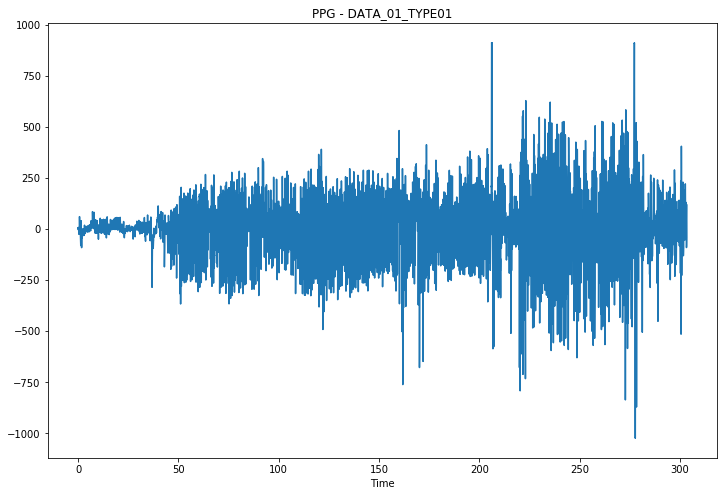

```python
plt.plot(ts, ppg2)
plt.title("PPG - DATA_01_TYPE01")
plt.xlabel("Time")
plt.show()
```

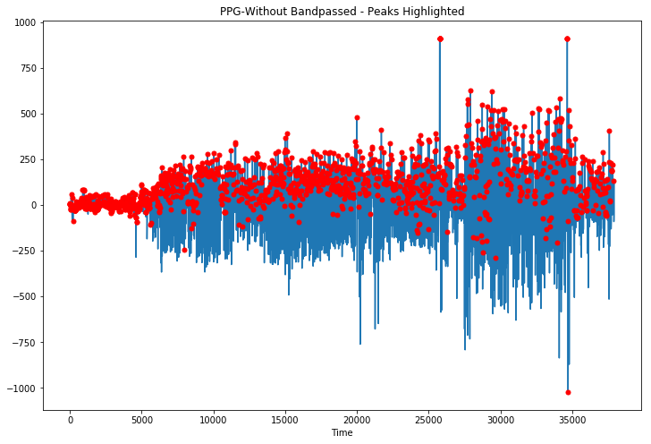

```python
#PPG chart Without bandpass
pks = sp.signal.find_peaks(ppg2)[0]
plt.plot(ppg2)
plt.plot(pks, ppg2[pks], 'r.', ms=10)
plt.title("PPG-Without Bandpassed - Peaks Highlighted")
plt.xlabel("Time")
plt.show()
```

#### From the chart above, it would be difficult to determine the BMP just using the PPG as there seems to be interferences from accelerometer signals.

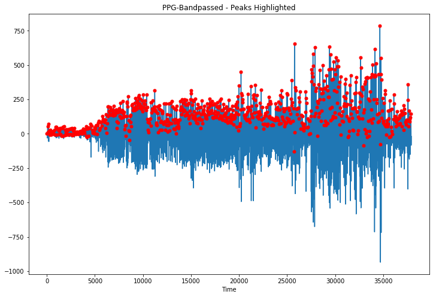

```python
#PPG chart With bandpass
ppg2_filtered = bandpass_filter(ppg2,fs)
pks = sp.signal.find_peaks(ppg2_filtered)[0]
plt.plot(ppg2_filtered)
plt.plot(pks, ppg2_filtered[pks], 'r.', ms=10)
plt.title("PPG-Bandpassed - Peaks Highlighted")
plt.xlabel("Time")
plt.show()
```

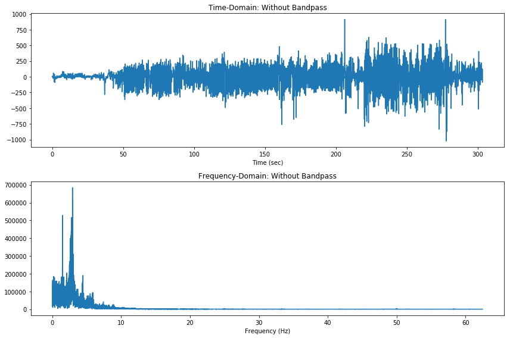

```python
#Without bandpass

freqs = np.fft.rfftfreq(len(ppg2), 1/fs)
fft = np.fft.rfft(ppg2)

plt.figure(figsize=(12, 8))
plt.subplot(2,1,1)
plt.plot(ts, ppg2)
plt.title('Time-Domain: Without Bandpass')
plt.xlabel('Time (sec)')
plt.subplot(2,1,2)
plt.plot(freqs, np.abs(fft))
plt.title('Frequency-Domain: Without Bandpass')
plt.xlabel('Frequency (Hz)')
plt.tight_layout()
```

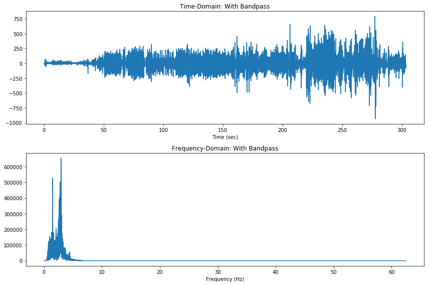

```python
#With bandpass
ppg2_filtered = bandpass_filter(ppg2,fs)

freqs_filtered = np.fft.rfftfreq(len(ppg2_filtered), 1/fs)
fft_filtered = np.fft.rfft(ppg2_filtered)

plt.figure(figsize=(12, 8))
plt.subplot(2,1,1)
plt.plot(ts, ppg2_filtered)
plt.title('Time-Domain: With Bandpass')
plt.xlabel('Time (sec)')
plt.subplot(2,1,2)
plt.plot(freqs_filtered, np.abs(fft_filtered))
plt.title('Frequency-Domain: With Bandpass')
plt.xlabel('Frequency (Hz)')
plt.tight_layout()
```

### Look at Frequency Harmonics to determine the window bandwidth to calculate peaked spectral energy

Looks like 1hz width should be OK for half-window width.

[figure not shown]

```python
freq_new = []
fft_new = []
for f, a in zip(freqs_filtered,np.abs(fft_filtered)):
    if (a > 100000):
        freq_new.append(f)
        fft_new.append(a)

plt.plot(f_new, a_new)
plt.title("Frequency Domain With Filtered FFT")
plt.xlable("Frequency")
```

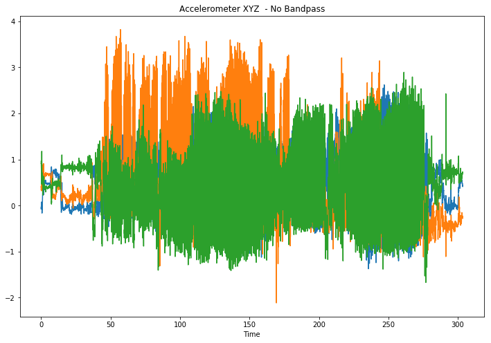

```python
plt.plot(ts,accx)
plt.plot(ts,accy)
plt.plot(ts,accz)
plt.title("Accelerometer XYZ  - No Bandpass")
plt.xlabel("Time")
plt.show()
```

#### The chart shows that xyz accelerometer series seem overlap significantly.

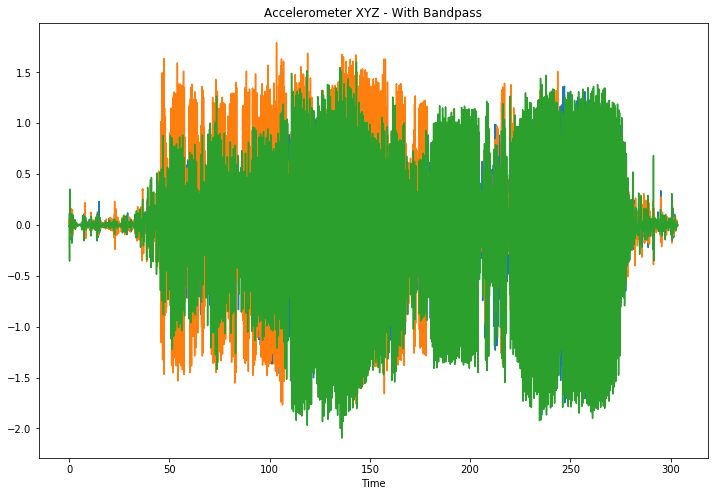

```python
accx_filtered = bandpass_filter(accx, fs)
accy_filtered = bandpass_filter(accy, fs)
accz_filtered = bandpass_filter(accz, fs)

plt.plot(ts,accx_filtered)
plt.plot(ts,accy_filtered)
plt.plot(ts,accz_filtered)

plt.title("Accelerometer XYZ - With Bandpass")
plt.xlabel("Time")
plt.show()
```

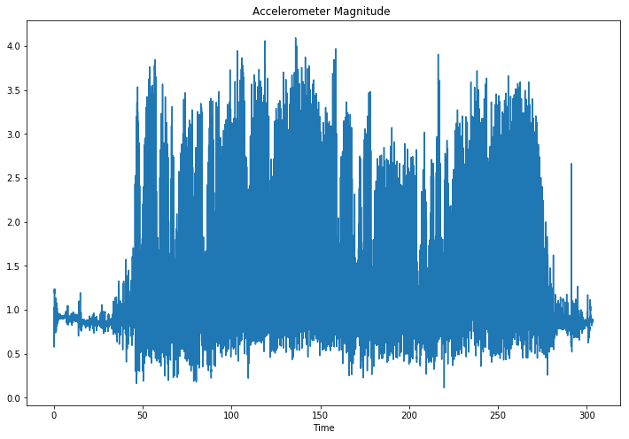

```python
# Magnitude of acceleration
acc = np.sqrt(accx**2 + accy**2 + accz**2)
plt.plot(ts,acc)
plt.title("Accelerometer Magnitude ")
plt.xlabel("Time")
plt.show()
```

### Project Write-up

Answer the following prompts to demonstrate understanding of the algorithm you wrote for this specific context.

> - **Code Description** - Include details so someone unfamiliar with your project will know how to run your code and use your algorithm.
> - **Data Description** - Describe the dataset that was used to train and test the algorithm. Include its short-comings and what data would be required to build a more complete dataset.
> - **Algorithhm Description** will include the following:
>   - how the algorithm works
>   - the specific aspects of the physiology that it takes advantage of
>   - a describtion of the algorithm outputs
>   - caveats on algorithm outputs
>   - common failure modes
> - **Algorithm Performance** - Detail how performance was computed (eg. using cross-validation or train-test split) and what metrics were optimized for. Include error metrics that would be relevant to users of your algorithm. Caveat your performance numbers by acknowledging how generalizable they may or may not be on different datasets.

Your write-up goes here...

### Code Description

The project algorithm is used to estimate the heart rate from the provided [TROIKA](https://ieeexplore.ieee.org/document/6905737) dataset with associated confidence level based on the spectral energy calculated at the pulse rate fequency.

The required library imports are specifed on the top of the code section.

To run the algorightm on training dataset:

- Ensure that the "data_dir" variable in the function LoadTroikaDataset is set to the directory that contains the TROIKA data files.
- Run the Evaluate() function which will return the MAE. The MAE is calculated based on the BMP estimates and confidence metrics
- A series of EDA to evaluate the data included in the notebook. Charts of PPG and Accelerometer were analyzed with/out various filters including band-pass parameters.

### Data Description

[TROIKA](https://ieeexplore.ieee.org/document/6905737) - "A General Framework for Heart Rate Monitoring Using Wrist-Type Photoplethysmographic Signals During Intensive Physical Exercise"

- Two-channel PPG signals, three-axis acceleration signals, and one-channel ECG signals were simultaneously recorded from subjects with age from 18 to 35 running on treadmills.
- All signals were sampled at 125 Hz and sent to a nearby computer via Bluetooth.
- A calculated ground-truth heart rate stored in the datasets with the corresponding name, say 'REF_01_TYPE01 under the variable "BMP0"
- BPM value is in every 8-second time window providing the ground truth.

### Algorithm Description

#### The algorithm works as follows:

- Loads all the files retrieving the PPG and accelerometer signals.
- The accelerometer three-axis signals were combined to a magnitude = np.sqrt(accx_filtered^2 + accy_filtered^2 + accz_filtered^2
- Bandpasses the signals between 40 BMP and 240 BMP
- For each file, the signals are split into chunks with 8 seconds in width window and shifted every 2 seconds for processing.
- The pulse rate and the confidence estimates are caculated using Fast Fourier Transform.
- With the frequency and FFT coefficients, the BMPs are determined with corresponding confidence.
  - Confidence levels are based on the spectral energy/intensity for the highest FFT.
  - If frequency of the PPG is the same as Accelerometer where the pulse is sampled, a second highest frequency of the PPG is checked to see if it has higher energy. If so, the algorithm uses the second frequency indicating the first frequency might have been spurious measurement from the accelerometer.
- After all chunks are processed for each file, the MAE (Mean Absolute Error) based on the estimates and ground-truth is calculated.
- The MAE calculation also uses the 10 percentile of confidence."The best 90% of the estimates are above the 10th percentile confidence", per project specification.
- The MAE value is returned as the final output of the algorithm.

#### Algorithm Performance

Results: MAE for train data was 16.75 and 8.02 for test data. Looks like the test data was much easier to estimate the training data.

Some parameters seem to have an impact on the MAE such as the bandpass and width window used to calculate the spectral enegery/intensity for confidence levels. Although the bandpass frequency is limited to 40 and 240 bmp for lower and upper limites respectively, changing them can impact the MAE. For example, increasing the upper limit to 300 bmp would improve the MAE. Perhaps, the improvement is due to cleaner signal at this high frequency. However, I think that this change would lead to overfitting making the algorithm to be less generalizable on unseen data.

Also, the dataset seems to be generated from a small number of subjects running on the treadmill. The uniform behavior of each subject can have biased metrics further making the algorithm less generalizable. perhaps, using leave-one-out cross-validation would minimize the bias.

### Next Steps

You will now go to **Test Your Algorithm** to apply a unit test to confirm that your algorithm met the success criteria.

[figure not shown]